# Analyse statistique et stylométrie avec R

JBC & SG

14/02/2018

# Mise en place de la session de travail

## Dossier de travail

Pour commencer, il faut spécifier à `R` le répertoire de travail courant (le dossier dans lequel vous travaillez, où sera sauvegardée votre session, et où se trouvent les fichiers à importer, etc.)

Dans `Rstudio`, vous pouvez le faire en cliquant sur `session/set working directory/to source file location`.

Sinon, vous pouvez spécifier l’adresse avec la commande `setwd()` (set working directory). L’adresse dépendera de l’endroit où se trouve le dossier sur l’arborescence de votre système de fichier, et de votre système d’exploitation (Unix ou non-Unix). Sur le poste de l’auteur, cela donne:

```r
#À modifier selon votre configuration locale !
setwd("~/Data/F/Cours, interventions, colloques,/2018-02-12_Neuchatel/github/14_R")
```

# Un peu de stylométrie du théâtre du XVIIe siècle

## Préparation et import des données

Une fois le corpus prêt, la première étape pour pouvoir l’utiliser dans R est d’y importer les données. En général, on travaillera avec des données dans un format tabulaire (CSV).

Pour importer le csv du corpus

```r
#Je charge un csv, en donnant l'adresse, le séparateur de colonnes, les entêtes et étiquettes de lignes
theatre = as.data.frame(read.csv(file="Frequences.csv", sep = ";", header = TRUE, row.names=1, quote = '\"'))
```

Je peux à présent les visualiser

```r
#View(theatre)
```

## Distributions

Si l’on souhaite examiner une distribution avec R, on peut utiliser la fonction `plot()` pour un graphe de dispersion, ainsi que `hist()` pour un histogramme.

*Nombre de mots des textes:*

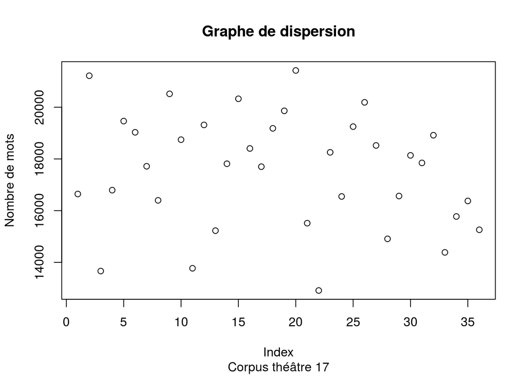

```r
#Graphe de dispersion
plot(colSums(theatre), ylab = "Nombre de mots", main="Graphe de dispersion", sub="Corpus théâtre 17")
```

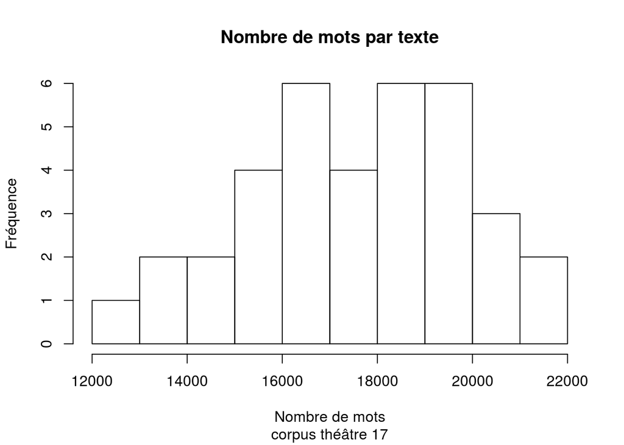

```r
#Histogramme
hist(colSums(theatre), main = "Nombre de mots par texte", sub="corpus théâtre 17", xlab = "Nombre de mots", ylab = "Fréquence")
```

On peut aussi examiner un certains nombre d’indicateurs très courants (moyenne, quartiles, médiane) Description:

```r
#Résumé de la variable
summary(colSums(theatre))
```

```
##    Min. 1st Qu.  Median    Mean 3rd Qu.    Max.
##   12912   16225   17830   17571   19200   21421
```

```r
#Calcul de l'écart type
sd(colSums(theatre))
```

```
## [1] 2201.572
```

```r
#Calcul de la variance
var(colSums(theatre))
```

```
## [1] 4846920
```

*Question* : de quel type de distribution se rapproche-t-on ? La moyenne est-elle significative ?

Examinons enfin quelques éléments supplémentaires sur cette distribution.

Voyons à présent à quel point cette distribution est asymétrique:

```r
library(moments)
#L'asymétrie (skewness)
skewness(colSums(theatre))
```

```
## [1] -0.2749223
```

```r
#L'aplatissement (kurtosis)
kurtosis(colSums(theatre))
```

```
## [1] 2.266444
```

NB: nous avons ici chargé un module complémentaire de R (`moments`). Il est possible qu’il vous faille l’installer (voir l’annexe).

Et examinons quelques autres indicateurs de dispersion, comme le *mode*,

```r
#Calculons le mode
library(modeest)
```

```r
mlv(colSums(theatre), method = "mfv")
```

```
## Mode (most likely value): 17571.17
## Bickel's modal skewness: 0.1666667
## Call: mlv.default(x = colSums(theatre), method = "mfv")
```

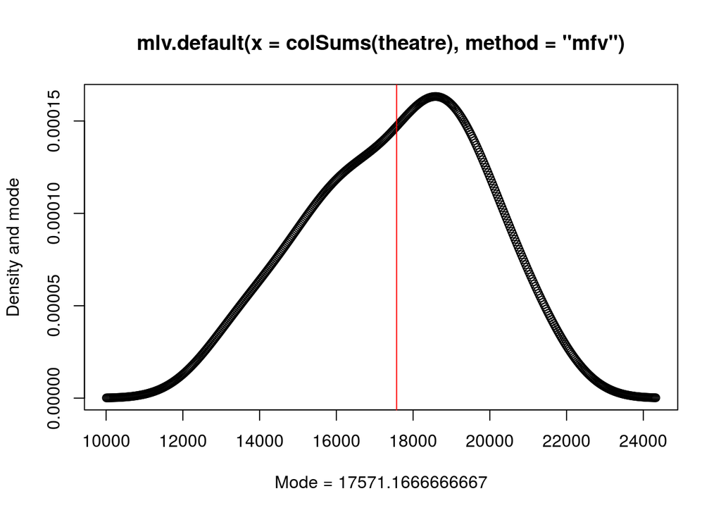

```r
plot(mlv(colSums(theatre), method = "mfv"))
```

Et observons la répartition selon ses différents quartiles:

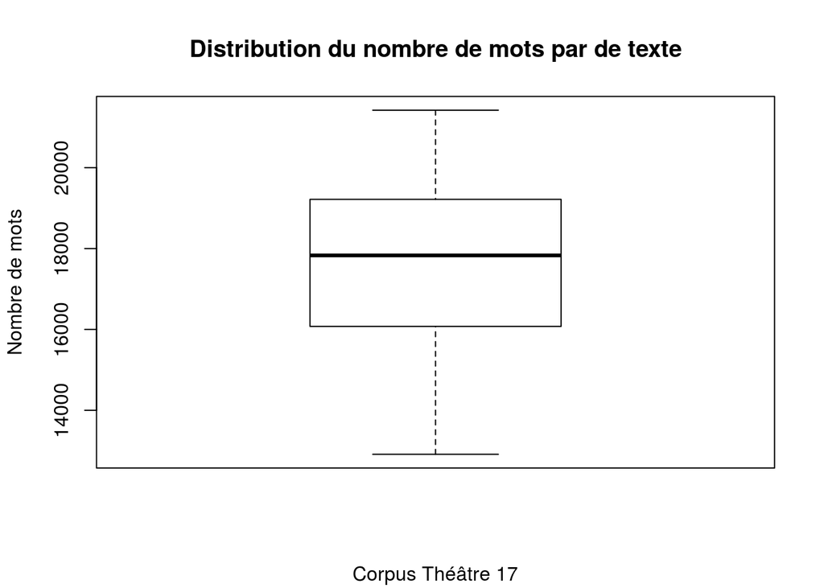

```r
boxplot(colSums(theatre), main = "Distribution du nombre de mots par de texte", ylab="Nombre de mots", sub="Corpus Théâtre 17")
```

*Question:* Le corpus est-il homogène, et peut-on le conserver sous cette forme ?

Si cette boîte à moustaches fait ressortir un point aberrant, on peut l’identifier et le retirer des données.

```r
#Je veux les individus possédant les valeurs les plus hautes ou les plus basses
head(colSums(theatre[order(colSums(theatre))]))
```

```
##         RACINE_ESTHER      BOYER_ARISTODEME CORNEILLET_BRADAMANTE
##                 12912                 13664                 13771
##   SCUDERY_MORTDECESAR ROTROU_HERCULEMOURANT      DURYER_CLARIGENE
##                 14386                 14910                 15226
```

```r
tail(colSums(theatre[order(colSums(theatre))]))
```

```
##       MOLIERE_MISANTHROPE       ROTROU_DEUXPUCELLES
##                     19860                     20188
##            DURYER_DYNAMIS   CORNEILLET_AMOURALAMODE
##                     20326                     20517
## BOYER_AMOURSJUPITERSEMELE          MOLIERE_TARTUFFE
##                     21217                     21421
```

Une fois l’individu identifié, on peut aussi avoir recours à la lecture proche pour comprendre la cause du problème.

On peut alors le retirer du sous-corpus, et recréer une table de fréquence (cette manière de procéder est préférable, car elle évite de créer des problèmes dans l’ordre global de fréquence, dans les hapax propres aux textes que l’on retire, etc.).

*Fréquences absolues des mots*

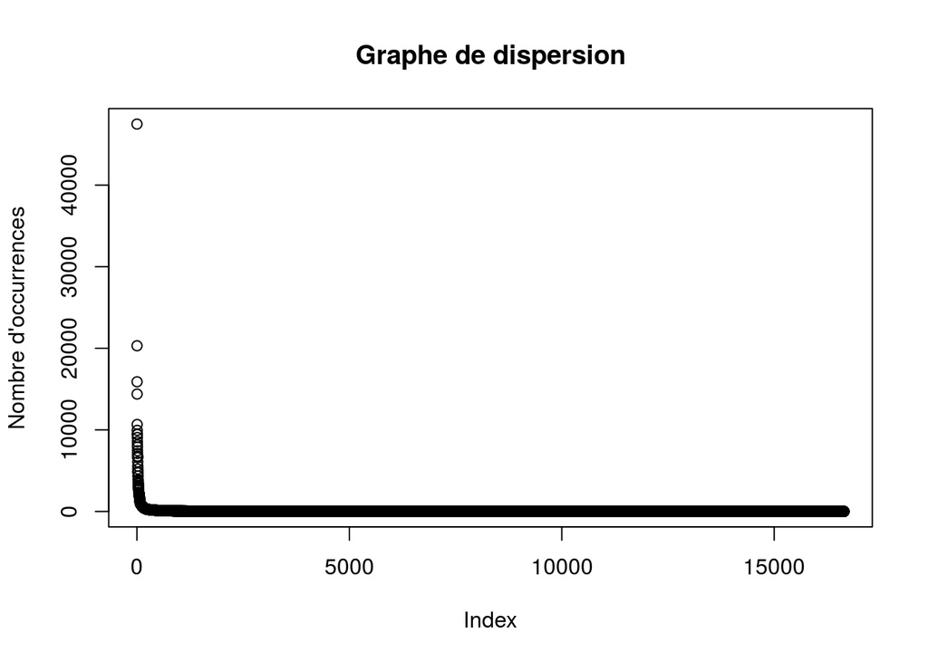

```r
plot(rowSums(theatre), ylab = "Nombre d'occurrences", main="Graphe de dispersion")
```

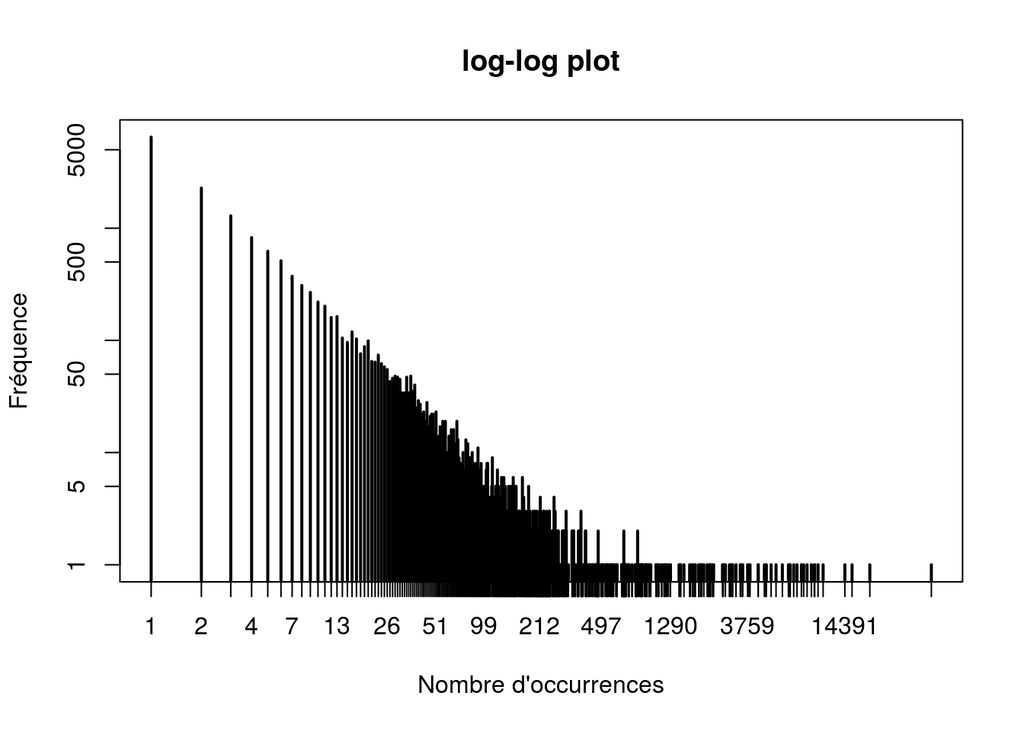

```r
#Log log plot
plot(table(rowSums(theatre)), ylab = "Fréquence", xlab = "Nombre d'occurrences", main="log-log plot", ylim = c(1,6500),log="xy")
```

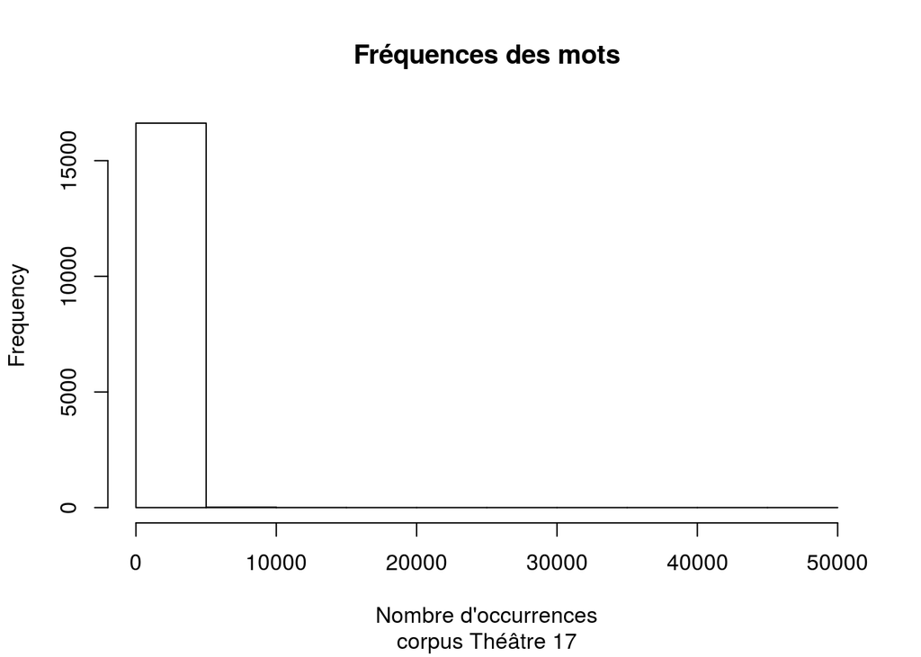

```r
hist(rowSums(theatre), main="Fréquences des mots", sub="corpus Théâtre 17", xlab = "Nombre d'occurrences")
```

Ouch ! Configurons un peu…

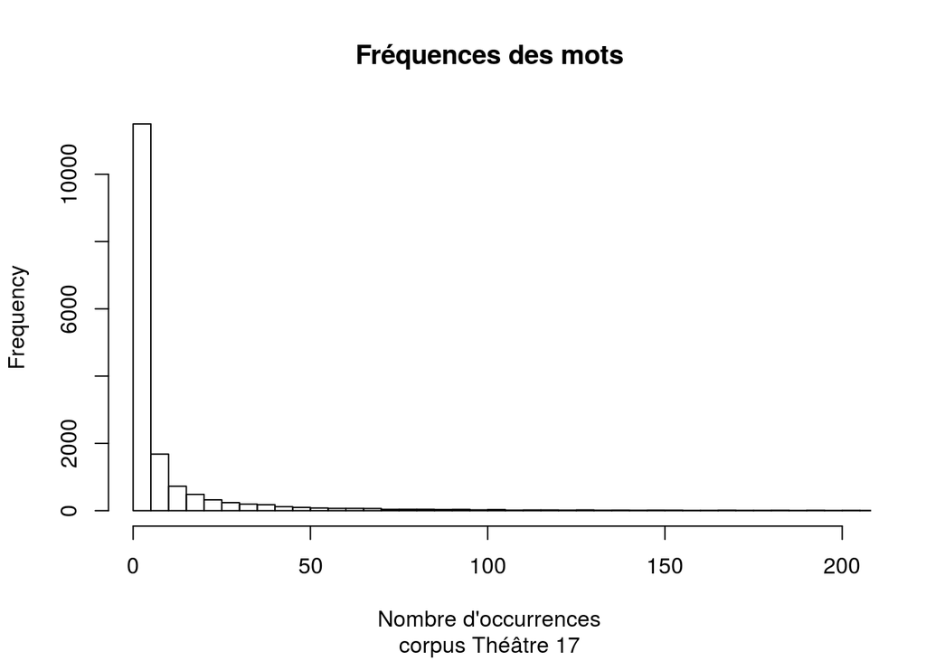

```r
hist(rowSums(theatre), breaks=10000, main="Fréquences des mots", sub="corpus Théâtre 17", xlab = "Nombre d'occurrences", xlim=c(1,200))
```

Et nos indicateurs:

```r
#Résumé
summary(rowSums(theatre))
```

```
##     Min.  1st Qu.   Median     Mean  3rd Qu.     Max.
##     1.00     1.00     2.00    38.01     8.00 47483.00
```

```r
#Écart-type
sd(rowSums(theatre))
```

```
## [1] 526.0065
```

```r
#Variance
var(rowSums(theatre))
```

```
## [1] 276682.9
```

*Question* : de quel type de distribution se rapproche-t-on ? La moyenne arithmétique est-elle pertinente?

Calculons la moyenne géométrique:

```r
exp(mean(log(rowSums(theatre))))
```

```
## [1] 3.596112
```

## Pré-traitements

Dans une perspective d’analyse stylométrique, plus particulièrement pour travailler sur l’attribution (ou la datation, la localisation), il est fréquent de sélectionner uniquement les mots les plus fréquents. Essayons de nous limiter aux 100 les plus fréquents, en travaillant en fréquences relatives:

```r
#Fréquences relatives
theatreTraite = theatre
for(i in 1:ncol(theatreTraite)){
        theatreTraite[,i] = theatreTraite[,i]/sum(theatreTraite[,i])
}

#N plus fréquents
#Faire varier le chiffre en dessous pour tenter d'autres sélections
theatreTraite = theatreTraite[1:100,]
```

NB: vous pouvez modifier cette commande pour prendre en compte les 200, 300, 500… mots les plus fréquents.

## Partitionnement

Passons à présent à la classification ascendante hiérarchique, et cherchons à voir comment se répartissent nos textes dans un dendrogramme.

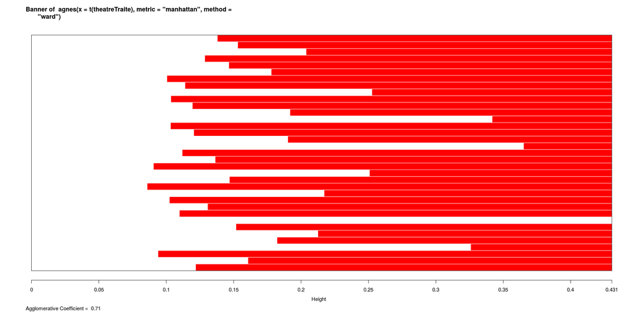

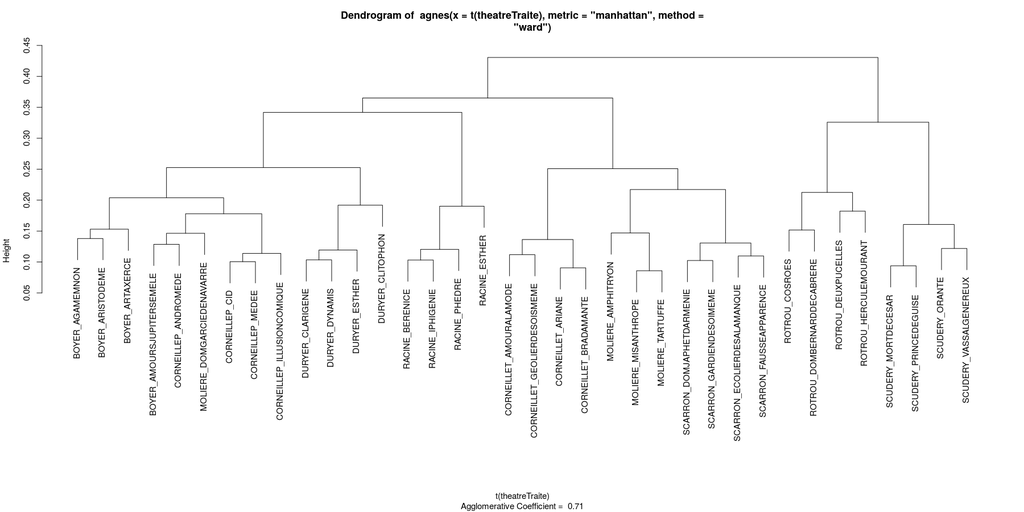

```r
#J'importe une bibliothèque de partitionnement
library(cluster)
maCAH = agnes(t(theatreTraite), metric = "manhattan", method="ward")
plot(maCAH)
```

```r
#Je garde celle-ci pour plus tard
maCAHaGarder = maCAH
```

### Mesures de distance et méthode d’agglomération

Varions éventuellement les mesures de distance, en utilisant la *distance de Canberra*. NB: comme celle-ci est absente de la fonction `agnes()` en elle-même, nous la calculerons avec la fonction `dist()`.

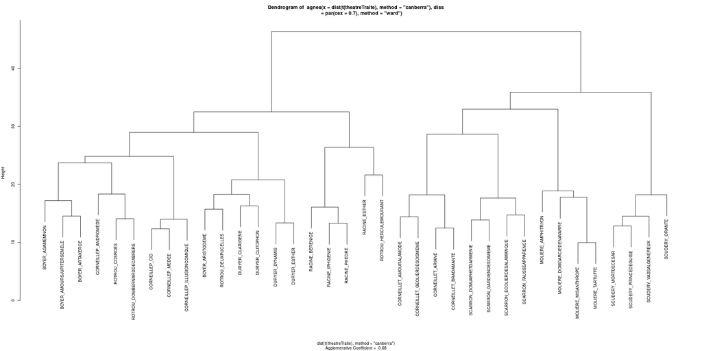

```r
maCAH = agnes(dist(t(theatreTraite), method="canberra"), method="ward", par(cex=0.7))
plot(maCAH,which.plots = 2)
```

Testons éventuellement avec un changement de méthode d’agglomération, en optant pour du *complete linkage*.

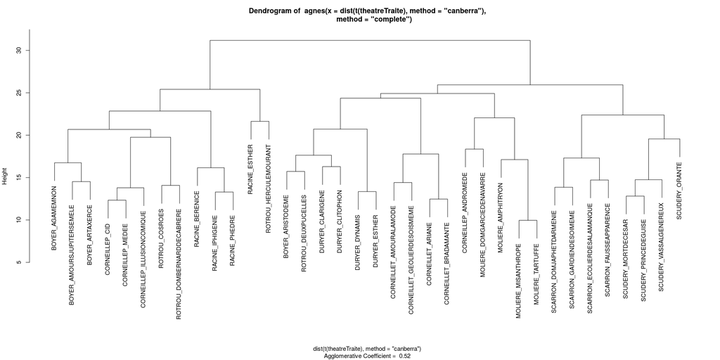

```r
maCAH = agnes(dist(t(theatreTraite), method="canberra"), method="complete")
plot(maCAH, which.plots = 2)
```

### Mesures de distance spécifiques à la stylométrie

Parmi les métriques un peu plus exotiques employées en stylométrie, on trouve la similarité cosinus.

```r
library(stylo)
```

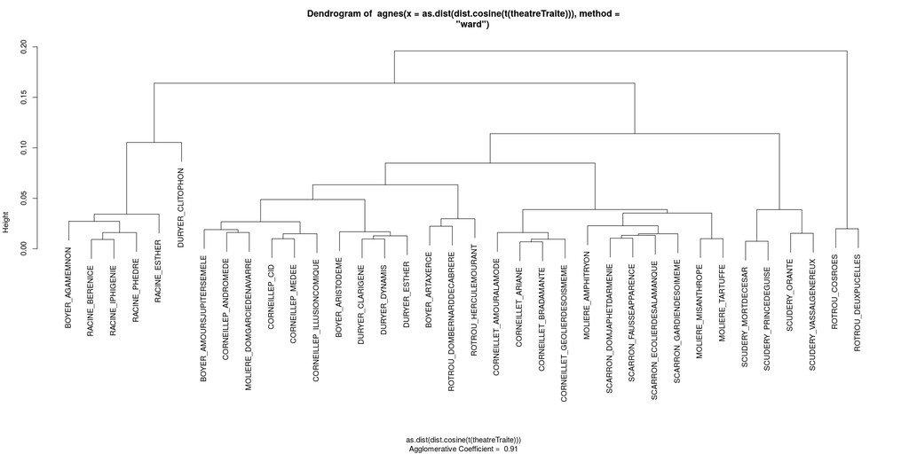

```r
maCAH = agnes(as.dist(dist.cosine(t(theatreTraite))), method="ward")
plot(maCAH,which.plots = 2)
```

La stylométrie a aussi développé ses propres mesures de distance. Une d’entre elles, parmi les plus récentes, est la métrique ‘min max’ (Koppel & Winter, 2014). Comme elle n’est pas encore implémentée dans R, nous allons la programmer (ça demande un peu plus d’effort).

```r
#Create a matrix with as much rows and cols as individuals
myDist = matrix(nrow = ncol(theatreTraite),ncol = ncol(theatreTraite), dimnames = list(colnames(theatreTraite),colnames(theatreTraite)))

for(i in 1:ncol(theatreTraite)){
  for(j in 1:ncol(theatreTraite)){
    min = sum(apply(cbind(theatreTraite[,i],theatreTraite[,j]), 1, min))
    max = sum(apply(cbind(theatreTraite[,i],theatreTraite[,j]), 1, max))
    resultat = 1 - (min / max)
    myDist[i,j] = resultat
  }
}
```

Et réalisons maintenant la CAH

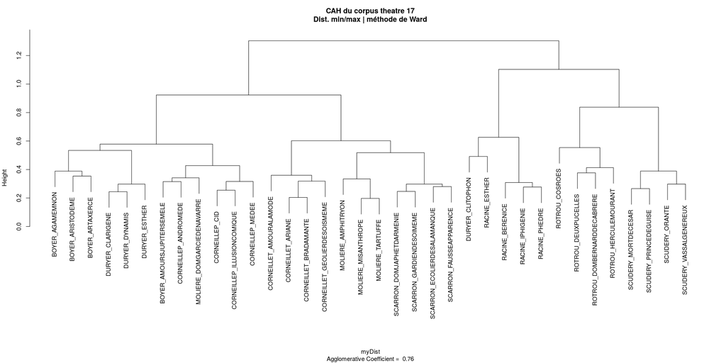

```r
maCAH = agnes(myDist,method="ward")
plot(maCAH, which.plots = 2, main = "CAH du corpus theatre 17\nDist. min/max | méthode de Ward")
```

```r
#Je garde celle-ci pour plus tard
#maCAHaGarder = maCAH
```

N.B.: si je considère que cette métrique min / max peut encore m’être utile, je peux même créer une nouvelle fonction de R:

```r
MinMax =
function(x){
  myDist = matrix(nrow = ncol(x),ncol = ncol(x), dimnames = list(colnames(x),colnames(x)))
  for(i in 1:ncol(x)){
    for(j in 1:ncol(x)){
      min = sum(apply(cbind(x[,i],x[,j]), 1, min))
      max = sum(apply(cbind(x[,i],x[,j]), 1, max))
      resultat = 1 - (min / max)
      myDist[i,j] = resultat
    }
  }
  return(myDist)
}
```

## Pré-traitements 2

Plutôt que d’opérer une sélection sèche des *n* mots les plus fréquents, il est possible également de sélectionner manuellement les mots-outils dans la liste de fréquence

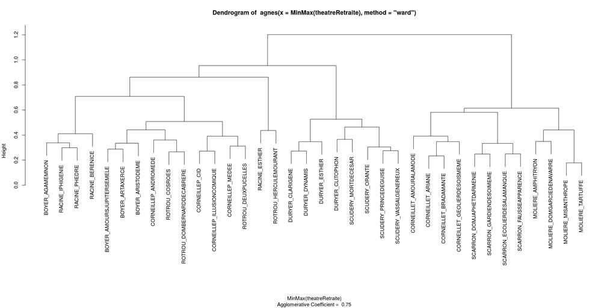

```r
#Import
theatre2 = as.data.frame(read.csv(file="Frequences_selectionnees.csv", sep = ";", header = TRUE, row.names=1, quote = '\"'))
theatreRetraite = theatre2
#Fréquences relatives
for(i in 1:ncol(theatreRetraite)){
        theatreRetraite[,i] = theatreRetraite[,i]/sum(theatreRetraite[,i])
}
#maCAH = agnes(t(theatreRetraite), metric = "manhattan", method="ward")
maCAH = agnes(MinMax(theatreRetraite), method="ward")
plot(maCAH,which.plots = 2)
```

## Description des classes

Pour savoir ce qui caractérise tel ou tel groupe, il est possible de regrouper les textes en plusieurs classes, et de calculer leurs spécificités. Le nombre de classes est à choisir en fonction du dendrogramme, et l’on peut s’aider d’un graphe des hauteurs (qui correspondent aux hauteurs où s’effectuent les séparations des branches du dendrogramme).

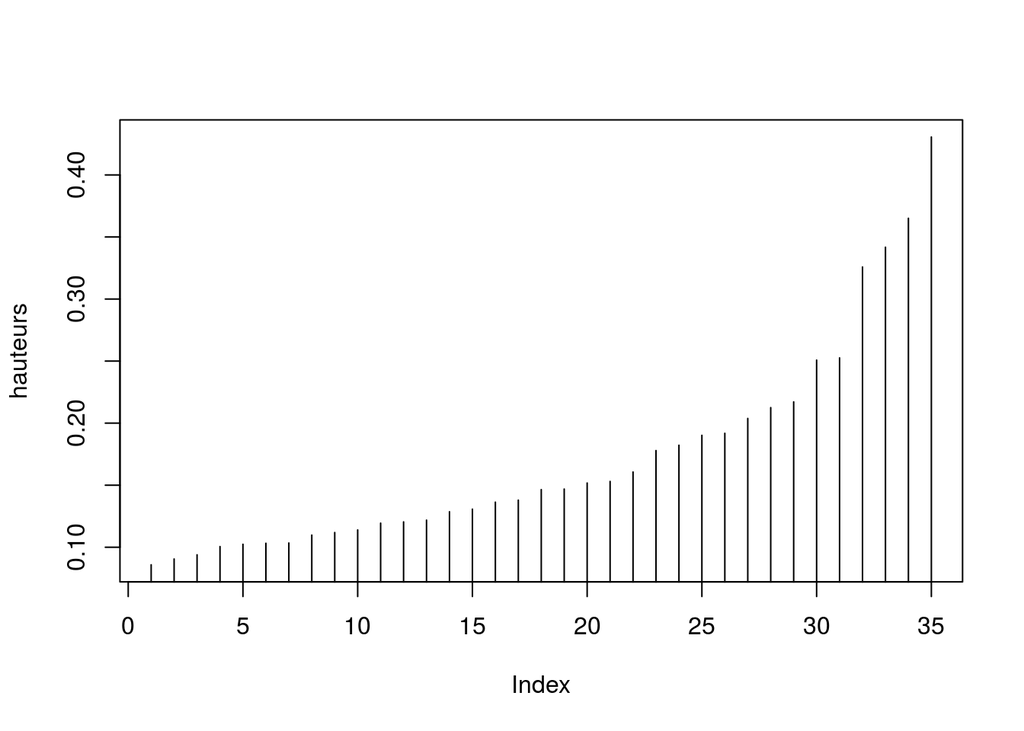

```r
maCAH = maCAHaGarder
maCAH2 = as.hclust(maCAH)
plot(maCAH2$height, type="h", ylab="hauteurs")
```

On remarque des sauts importants entre la première et la deuxième, la quatrième et la cinquième, et la sixième et la suite.

En coupant après la sixième, j’obtiens presque des groupes par auteur. Je peux choisir cette hauteur.

```r
#Je découpe en classes
classes = cutree(maCAH, k = "7")
#J'ajoute les classes à mon tableau
theatreTraiteAvecClasses = t(theatreTraite)
theatreTraiteAvecClasses = cbind(as.data.frame(theatreTraiteAvecClasses), as.factor(classes))
colnames(theatreTraiteAvecClasses)[101] = "Classes"

#Les classes
theatreTraiteAvecClasses[101]
```

```
##                              Classes
## BOYER_AGAMEMNON                    1
## BOYER_AMOURSJUPITERSEMELE          1
## BOYER_ARISTODEME                   1
## BOYER_ARTAXERCE                    1
## CORNEILLEP_ANDROMEDE               1
## CORNEILLEP_CID                     1
## CORNEILLEP_ILLUSIONCOMIQUE         1
## CORNEILLEP_MEDEE                   1
## CORNEILLET_AMOURALAMODE            2
## CORNEILLET_ARIANE                  2
## CORNEILLET_BRADAMANTE              2
## CORNEILLET_GEOLIERDESOISMEME       2
## DURYER_CLARIGENE                   3
## DURYER_CLITOPHON                   3
## DURYER_DYNAMIS                     3
## DURYER_ESTHER                      3
## MOLIERE_AMPHITRYON                 4
## MOLIERE_DOMGARCIEDENAVARRE         1
## MOLIERE_MISANTHROPE                4
## MOLIERE_TARTUFFE                   4
## RACINE_BERENICE                    5
## RACINE_ESTHER                      5
## RACINE_IPHIGENIE                   5
## RACINE_PHEDRE                      5
## ROTROU_COSROES                     6
## ROTROU_DEUXPUCELLES                6
## ROTROU_DOMBERNARDDECABRERE         6
## ROTROU_HERCULEMOURANT              6
## SCARRON_DOMJAPHETDARMENIE          4
## SCARRON_ECOLIERDESALAMANQUE        4
## SCARRON_FAUSSEAPPARENCE            4
## SCARRON_GARDIENDESOIMEME           4
## SCUDERY_MORTDECESAR                7
## SCUDERY_ORANTE                     7
## SCUDERY_PRINCEDEGUISE              7
## SCUDERY_VASSALGENEREUX             7
```

```r
#Boyer, P. Corneille, _Dom Garcie_ -> 1
#T. Corneille -> 2
#Duryer -> 3
#Molière, Scarron -> 4
#Racine -> 5
#Rotrou -> 6
#Scudéry -> 7

#Je charge FactoMineR
library(FactoMineR)
#Et je décrit les classes
mesClasses = catdes(theatreTraiteAvecClasses, num.var = 101)
mesClasses
```

```
## $quanti.var
##            Eta2      P-value
## .     0.8174159 1.719449e-09
## :     0.8049833 4.344709e-09
## faire 0.7340758 3.292472e-07
## ...   0.7223604 5.974101e-07
## on    0.7079983 1.196752e-06
## bien  0.7054633 1.347738e-06
## pas   0.6856546 3.288760e-06
## ;     0.6794610 4.293014e-06
## c'    0.6790452 4.369633e-06
## y     0.6647271 7.916679e-06
## la    0.6637153 8.247517e-06
## ?     0.6572134 1.069537e-05
## voir  0.6379382 2.240803e-05
## moi   0.6272446 3.315176e-05
## comme 0.6245974 3.645621e-05
## est   0.6107240 5.926663e-05
## mes   0.6063006 6.891496e-05
## si    0.5972895 9.315373e-05
## ses   0.5955744 9.856722e-05
## yeux  0.5934335 1.057279e-04
## des   0.5919818 1.108500e-04
## -vous 0.5638034 2.676724e-04
## enfin 0.5595000 3.044583e-04
## que   0.5576113 3.220099e-04
## je    0.5534832 3.636192e-04
## et    0.5525821 3.733279e-04
## il    0.5516449 3.836753e-04
## ,     0.5505630 3.959435e-04
## pour  0.5461388 4.499117e-04
## à     0.5388686 5.532608e-04
## m'    0.5338995 6.358232e-04
## amour 0.5300012 7.082439e-04
## mais  0.5261868 7.862627e-04
## qu'   0.5090201 1.242864e-03
## sur   0.5076580 1.287759e-03
## trop  0.5060591 1.342319e-03
## le    0.4964052 1.718463e-03
## suis  0.4939714 1.827176e-03
```

[output cut: 358 more lines]

```
## .     3.286522e-02
## j'    2.265600e-02
## -je   1.440781e-02
## avec  1.284313e-02
## moi   6.623135e-03
## d'    6.001511e-03
## ?     5.875911e-03
## -il   3.436260e-03
## sur   2.732000e-03
## -vous 2.195840e-03
## à     9.942819e-04
##
##
## attr(,"class")
## [1] "catdes" "list "
```

```r
plot(mesClasses)
```

[output not shown]